# churn analysis

Itzblend

17/10/2019

# **Churn analysis**

## **What is the problem we are solving here?**

#### Getting new customers is always way more expensive than retaining your excisting customers and make them come back for more. We are going to dig deep into the data and find out how we can make customers stay

```r
churndata <- read_csv("C:/Users/Mari/Documents/Lauri/churn_analysis/Telco Data.csv")
#churndata <- read_csv("~/Documents/churn_analysis/Telco Data.csv")

# Removing the customerID attribute as we wont be needing it in our algorithm
churndata$customerID <- NULL
```

### As the data we are predicting is either “Churn” or “Not Churn”, we are going to use Logistics regression which is a Linear classifier

### First off some data cleaning

```r
churndata$gender <- as.factor(churndata$gender)
churndata$SeniorCitizen <- as.factor(churndata$SeniorCitizen)
churndata$Partner <- as.factor(revalue(churndata$Partner, c("No" = 0, "Yes" = 1)))
churndata$Dependents <- as.factor(revalue(churndata$Dependents, c("No" = 0, "Yes" = 1)))
churndata$PhoneService <- as.factor(revalue(churndata$PhoneService, c("No" = 0, "Yes" = 1)))
churndata$InternetService <- as.factor(churndata$InternetService)
churndata$OnlineSecurity <- as.factor(churndata$OnlineSecurity)
churndata$MultipleLines <- as.factor(churndata$MultipleLines)
churndata$OnlineBackup <- as.factor(churndata$OnlineBackup)
churndata$DeviceProtection <- as.factor(churndata$DeviceProtection)
churndata$TechSupport <- as.factor(churndata$TechSupport)
churndata$StreamingTV <- as.factor(churndata$StreamingTV)
churndata$StreamingMovies <- as.factor(churndata$StreamingMovies)
churndata$Contract <- as.factor(churndata$Contract)
churndata$PaperlessBilling <- as.factor(revalue(churndata$PaperlessBilling, c("No" = 0, "Yes" = 1)))
churndata$PaymentMethod <- as.factor(churndata$PaymentMethod)
churndata$Churn <- as.factor(churndata$Churn)
```

Missing values

```r
missattrs <- sapply(churndata, function(x) sum(x == "" | is.na(x)))
missattrs # So only TotalCharges has some missing values
```

```
##           gender    SeniorCitizen          Partner       Dependents
##                0                0                0                0
##           tenure     PhoneService    MultipleLines  InternetService
##                0                0                0                0
##   OnlineSecurity     OnlineBackup DeviceProtection      TechSupport
##                0                0                0                0
##      StreamingTV  StreamingMovies         Contract PaperlessBilling
##                0                0                0                0
##    PaymentMethod   MonthlyCharges     TotalCharges            Churn
##                0                0               11                0
```

```r
names(which(missattrs > 0))
```

```
## [1] "TotalCharges"
```

```r
churndata[is.na(churndata$TotalCharges),]
```

```
## # A tibble: 11 x 20
##    gender SeniorCitizen Partner Dependents tenure PhoneService
##    <fct>  <fct>         <fct>   <fct>       <dbl> <fct>
##  1 Female 0             1       1               0 0
##  2 Male   0             0       1               0 1
##  3 Female 0             1       1               0 1
##  4 Male   0             1       1               0 1
##  5 Female 0             1       1               0 0
##  6 Male   0             1       1               0 1
##  7 Male   0             1       1               0 1
##  8 Female 0             1       1               0 1
##  9 Male   0             1       1               0 1
## 10 Female 0             1       1               0 1
## 11 Male   0             0       1               0 1
## # ... with 14 more variables: MultipleLines <fct>, InternetService <fct>,
## #   OnlineSecurity <fct>, OnlineBackup <fct>, DeviceProtection <fct>,
## #   TechSupport <fct>, StreamingTV <fct>, StreamingMovies <fct>,
## #   Contract <fct>, PaperlessBilling <fct>, PaymentMethod <fct>,
## #   MonthlyCharges <dbl>, TotalCharges <dbl>, Churn <fct>
```

```r
for (i in 1:nrow(churndata)){
  if (is.na(churndata$TotalCharges[i])){
    churndata$TotalCharges[i] <- median(churndata$TotalCharges, na.rm = TRUE)
  }
}

sapply(churndata, function(x) sum(x == "" | is.na(x)))
```

```
##           gender    SeniorCitizen          Partner       Dependents
##                0                0                0                0
##           tenure     PhoneService    MultipleLines  InternetService
##                0                0                0                0
##   OnlineSecurity     OnlineBackup DeviceProtection      TechSupport
##                0                0                0                0
##      StreamingTV  StreamingMovies         Contract PaperlessBilling
##                0                0                0                0
##    PaymentMethod   MonthlyCharges     TotalCharges            Churn
##                0                0                0                0
```

```r
names(which(missattrs > 0))
```

```
## [1] "TotalCharges"
```

Splitting the dataset into train and test

```r
traindata <- createDataPartition(y = churndata$Churn, p = 0.75, list = FALSE)
train <- churndata[traindata,]
test <- churndata[-traindata,]
```

Then into numerical and factors

```r
numerical_vars <- names(churndata[,sapply(churndata, is.numeric)])
num_df <- churndata[,names(churndata) %in% numerical_vars]

factor_vars <- names(churndata[,sapply(churndata, is.factor)])
factor_df <- churndata[,names(churndata) %in% factor_vars]
```

Checking for skewness

```r
skew(num_df)
```

```
## [1]  1686.360 -1552.492  6785.075
```

```r
for(i in 1:ncol(num_df)){
  if(abs(skew(num_df[,i])) > 0.8) {
    num_df[,i] <- log(num_df[,i] +1)
  }
}

skew(num_df)
```

```
## [1] -5479.723 -5061.878 -5241.292
```

Preprocessing the numerical variables

```r
preNum <- preProcess(num_df, method = c("center", "scale"))
print(preNum)
```

```
## Created from 7043 samples and 3 variables
##
## Pre-processing:
##   - centered (3)
##   - ignored (0)
##   - scaled (3)
```

```r
norm_df <- predict(preNum, num_df) # Last stage of numerical data
```

Normalizing the factor variables by making them dummy variables

```r
dummy_df <- as.data.frame(model.matrix(~.-1, factor_df))

zerocol <- which(colSums(dummy_df[1:nrow(dummy_df),]) == 0)
colnames(zerocol)
```

```r
less10 <- which(colSums(dummy_df[1:nrow(dummy_df),]) < 10)
colnames(less10)
```

```r
# Nothing to remove here
```

combining the numerical and factor datasets

```r
combined <- cbind(norm_df, dummy_df)
```

Fitting the model

```r
set.seed(205)
fit <- glm(Churn~., data = train, family = binomial)
```

Predicting the test set with train fit

```r
set.seed(205)
churn_probs <- predict(fit, test, type = "response")
head(churn_probs)
```

```
##          1          2          3          4          5          6
## 0.02649102 0.67764536 0.32129941 0.59775570 0.43089643 0.04143796
```

```r
contrasts(churndata$Churn)
```

```
##     Yes
## No    0
## Yes   1
```

```r
glm_pred = rep("No", length(churn_probs))
glm_pred[churn_probs > 0.5] = "Yes"
glm_pred <- as.factor(glm_pred)
```

Evaluating the model

```r
confusionMatrix(glm_pred, test$Churn, positive = "Yes")
```

```
## Confusion Matrix and Statistics
##
##           Reference
## Prediction   No  Yes
##        No  1155  201
##        Yes  138  266
##
##                Accuracy : 0.8074
##                  95% CI : (0.7882, 0.8256)
##     No Information Rate : 0.7347
##     P-Value [Acc > NIR] : 5.638e-13
##
##                   Kappa : 0.4837
##
##  Mcnemar's Test P-Value : 0.0007589
##
##             Sensitivity : 0.5696
##             Specificity : 0.8933
##          Pos Pred Value : 0.6584
##          Neg Pred Value : 0.8518
##              Prevalence : 0.2653
##          Detection Rate : 0.1511
##    Detection Prevalence : 0.2295
##       Balanced Accuracy : 0.7314
##
##        'Positive' Class : Yes
##
```

Digging deeper to sensitivity and specificity

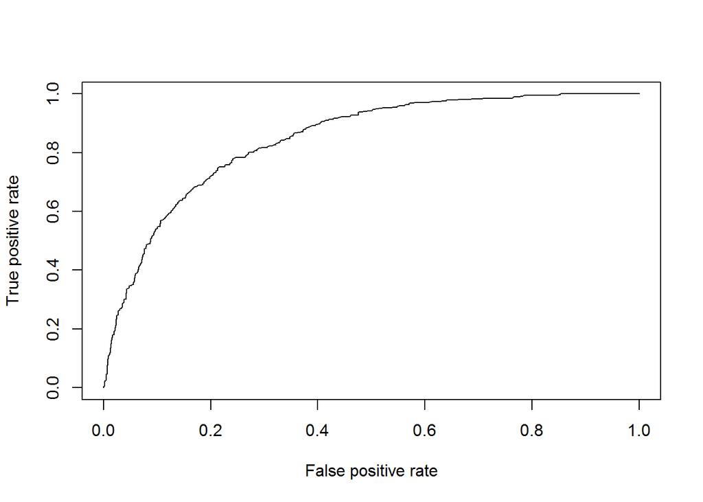

```r
# Creating prediction object
pred <- prediction(churn_probs, test$Churn)
# Plotting the ROC
prf <- performance(pred, measure = "tpr", x.measure = "fpr")
plot(prf)
```

Area Under the ROC Curve, known as the AUC

```r
auc <- performance(pred, measure = "auc")
auc <- auc@y.values[[1]]
auc
```

```
## [1] 0.8448639
```

```r
# Our models auc is way over 50% so its way more accurate than guessing. Business value here!
```

Improving the model with cross validation

```r
set.seed(205)

# Control
fitctrl <- trainControl(
  method = "repeatedcv",
  number = 10,
  repeats = 3,
  classProbs = TRUE,
  summaryFunction = twoClassSummary
)

# Logistic regression model
logreg <- train(Churn~., churndata,
                method = "glm",
                family = "binomial",
                trControl = fitctrl,
                metric = "ROC")
```

[output not shown]

[output cut: 124 more lines]

[output not shown]

```r
logreg
```

```
## Generalized Linear Model
##
## 7043 samples
##   19 predictor
##    2 classes: 'No', 'Yes'
##
## No pre-processing
## Resampling: Cross-Validated (10 fold, repeated 3 times)
## Summary of sample sizes: 6338, 6339, 6340, 6339, 6338, 6339, ...
## Resampling results:
##
##   ROC        Sens       Spec
##   0.8455255  0.8971822  0.550183
```

Comparing the cost

```r
# Fitting
fit <- glm(Churn~., data = train, family = binomial)

# Predicting
churn_probs <- predict(fit, test, type = "response")
```

Treshold and cost vectors

```r
thresh <- seq(0.1 ,1.0, length = 10)

cost = rep(0, length(thresh))
```

```r
for (i in 1:length(thresh)){

  glm_pred = rep("No", length(churn_probs))
  glm_pred[churn_probs > thresh[i]] = "Yes"
  glm_pred <- as.factor(glm_pred)
  x <- confusionMatrix(glm_pred, test$Churn, positive = "Yes")
  TN <- x$table[1]/1760
  FP <- x$table[2]/1760
  FN <- x$table[3]/1760
  TP <- x$table[4]/1760
  cost[i] = FN*300 + TP*60 + FP*60 + TN*0
}
```

Simple model

```r
glm_pred = rep("No", length(churn_probs))
glm_pred[churn_probs > 0.5] = "Yes"
glm_pred <- as.factor(glm_pred)

x <- confusionMatrix(glm_pred, test$Churn, positive = "Yes")
TN <- x$table[1]/1760
FP <- x$table[2]/1760
FN <- x$table[3]/1760
TP <- x$table[4]/1760
cost_simple = FN*300 + TP*60 + FP*60 + TN*0
```

Comparing the costs of optimized and simple model

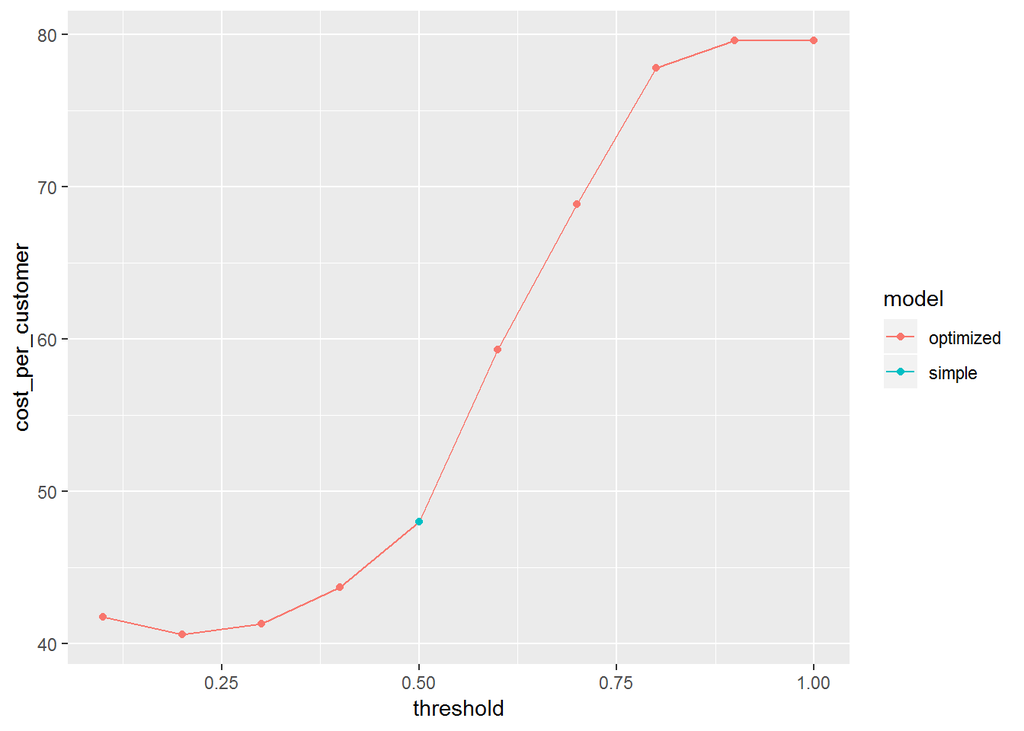

```r
cost_df <- data.frame(
  model = c(rep("optimized", 10),"simple"),
  cost_per_customer = c(cost, cost_simple),
  threshold = c(thresh, 0.5)
)

ggplot(cost_df, aes(x = threshold, y = cost_per_customer, group = model, color = model))+
  geom_line()+
  geom_point()
```

```r
### The lowest cost per customer is about 41$ at the threshold of 0.2 ###
```

Calculating the savings

```r
savings_per_customer <- cost_simple - min(cost)

total_savings <- 7043*savings_per_customer
total_savings
```

```
## [1] 52342.3
```